# Impacto do Consumo de Refrigerante Diet no Peso

Uma Réplica de um estudo realizado em 2024 usando critério backdoor

Autor

João Vitor Vasconcelos Lima

Data de Publicação

22 de março de 2026

**Código**

```r
library(pcalg)
library(dagitty)
library(igraph)
library(dplyr)
library(nhanesA)
library(ggplot2)
library(knitr)
library(kableExtra)

set.seed(42)
```

# 1 Introdução

Este documento replica a metodologia de @qi2024causality, que investigou o impacto causal do consumo de Diet Coke sobre a obesidade utilizando dados do **NHANES** (National Health and Nutrition Examination Survey) dos ciclos 2003–2004 e 2005–2006.

A contribuição central do artigo é substituir análises puramente associativas por inferência causal formal, empregando:

1. **Modelos Causais Estruturais (SCM)** e o algoritmo IC* para construção do diagrama causal;
2. **Critério Backdoor** para estimar a distribuição experimental (RCT) a partir de dados observacionais;
3. **Probabilidade de Necessidade e Suficiência (PNS)** como métrica de impacto causal individual, estratificada por subgrupos demográficos e dietéticos.

# 2 Dados

## 2.1 Fonte e variáveis

Os dados provêm do programa NHANES, administrado pelo CDC. Foram utilizados dois ciclos anuais que incluem a seção de Frequência de Consumo Alimentar (FFQ):

Tabela 1: Sumário das variáveis utilizadas

| Variável | Descrição | Codificação |
| --- | --- | --- |
| `exposicao_coca` | Consumo de Diet Coke (X) | 0 = nunca, 1 = qualquer frequência |
| `obesidade` | IMC ≥ 30 kg/m² (Y) | 0 = não obeso, 1 = obeso |
| `diabetes` | Diabetes diagnosticada (Z — confounder) | 0 = não, 1 = sim |
| `idade` | Idade em anos | Contínua |
| `genero` | Sexo biológico | Male / Female |
| `raca` | Raça/etnia | Categórica |
| `escolaridade` | Nível de instrução | Categórica ordinal |
| `fumo` | Fumou ≥ 100 cigarros na vida | 0 = não, 1 = sim |
| `atividade_fisica` | Nível de atividade (PAQ180) | 1 = muito ativo … 4 = sedentário |
| `hiperlipidemia` | Colesterol alto diagnosticado | 0 = não, 1 = sim |

## 2.2 Carregamento e limpeza

**Código**

```r
dados_nhanes <- readRDS("nhanes_completo_03_06.rds")

vars_modelo <- c("exposicao_coca", "obesidade", "idade", "genero", "raca",
                 "escolaridade", "fumo", "atividade_fisica",
                 "hiperlipidemia", "diabetes")
```

**Código**

```r
cat("Dimensões do dataset:", nrow(dados_nhanes), "linhas x",
    ncol(dados_nhanes), "colunas\n")
```

```
Dimensões do dataset: 4949 linhas x 13 colunas
```

**Código**

```r
dados_nhanes %>%
  summarise(
    n_total       = n(),
    prop_obesos   = round(mean(obesidade, na.rm = TRUE) * 100, 1),
    prop_expostos = round(mean(exposicao_coca, na.rm = TRUE) * 100, 1),
    prop_diabeticos = round(mean(diabetes, na.rm = TRUE) * 100, 1)
  ) %>%
  kable(
    col.names = c("N total", "% obesos", "% expostos (Diet Coke)", "% diabéticos"),
    caption   = "Estatísticas descritivas do dataset final"
  ) %>%
  kable_styling(bootstrap_options = c("striped", "hover"), full_width = FALSE)
```

Estatísticas descritivas do dataset final

| N total | % obesos | % expostos (Diet Coke) | % diabéticos |
| --- | --- | --- | --- |
| 4949 | 35 | 31 | 10.4 |

## 2.3 Distribuição das variáveis principais

**Código**

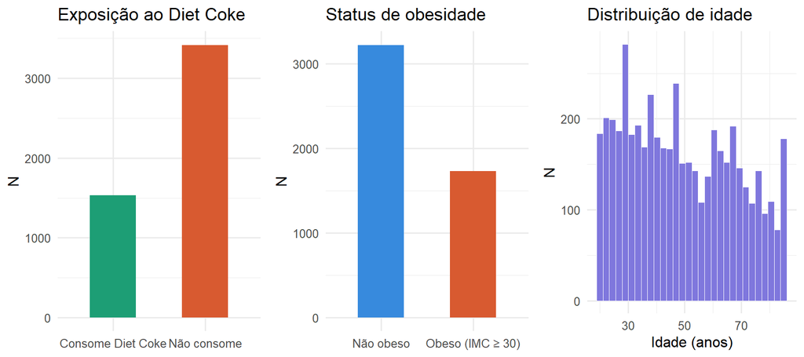

```r
p1 <- dados_nhanes %>%
  mutate(exposicao = ifelse(exposicao_coca == 1, "Consome Diet Coke", "Não consome")) %>%
  ggplot(aes(x = exposicao, fill = exposicao)) +
  geom_bar(width = 0.5) +
  scale_fill_manual(values = c("#1D9E75", "#D85A30")) +
  labs(title = "Exposição ao Diet Coke", x = NULL, y = "N") +
  theme_minimal(base_size = 12) +
  theme(legend.position = "none")

p2 <- dados_nhanes %>%
  mutate(status = ifelse(obesidade == 1, "Obeso (IMC ≥ 30)", "Não obeso")) %>%
  ggplot(aes(x = status, fill = status)) +
  geom_bar(width = 0.5) +
  scale_fill_manual(values = c("#378ADD", "#D85A30")) +
  labs(title = "Status de obesidade", x = NULL, y = "N") +
  theme_minimal(base_size = 12) +
  theme(legend.position = "none")

p3 <- dados_nhanes %>%
  ggplot(aes(x = idade)) +
  geom_histogram(bins = 30, fill = "#7F77DD", color = "white", linewidth = 0.3) +
  labs(title = "Distribuição de idade", x = "Idade (anos)", y = "N") +
  theme_minimal(base_size = 12)

gridExtra::grid.arrange(p1, p2, p3, ncol = 3)
```

# 3 Diagrama Causal

## 3.1 Algoritmo FCI (IC*)

O algoritmo IC*, implementado como FCI (*Fast Causal Inference*) no pacote `pcalg`, constrói um PAG (*Partial Ancestral Graph*) a partir de testes de independência condicional. Diferentemente do algoritmo PC, o FCI admite a presença de variáveis latentes, o que é mais adequado ao contexto observacional do NHANES.

**Código**

```r
# Preparar matriz para o FCI
df_model <- dados_nhanes[, vars_modelo]
df_model[] <- lapply(df_model,
                     function(x) suppressWarnings(as.numeric(as.character(x))))

# Remover colunas com > 60% de NAs ou variância zero
colunas_validas <- sapply(df_model, function(x) {
  n_ok <- sum(!is.na(x))
  vari <- var(x, na.rm = TRUE)
  n_ok / nrow(df_model) >= 0.4 && !is.na(vari) && vari > 0
})
df_model <- df_model[, colunas_validas, drop = FALSE]

# Normalizar variáveis contínuas
df_model$idade <- as.numeric(scale(df_model$idade))
df_model       <- df_model[complete.cases(df_model), ]

# Matriz de correlação e FCI
mat_cor  <- cor(df_model, use = "complete.obs")
suffStat <- list(C = mat_cor, n = nrow(df_model))

fci_fit <- fci(
  suffStat  = suffStat,
  indepTest = gaussCItest,
  alpha     = 0.01,
  p         = ncol(df_model),
  labels    = colnames(df_model),
  verbose   = FALSE
)

cat("FCI concluído —", ncol(df_model), "variáveis,", nrow(df_model), "observações\n")
```

```
FCI concluído — 6 variáveis, 3404 observações
```

## 3.2 Visualização do PAG

**Código**

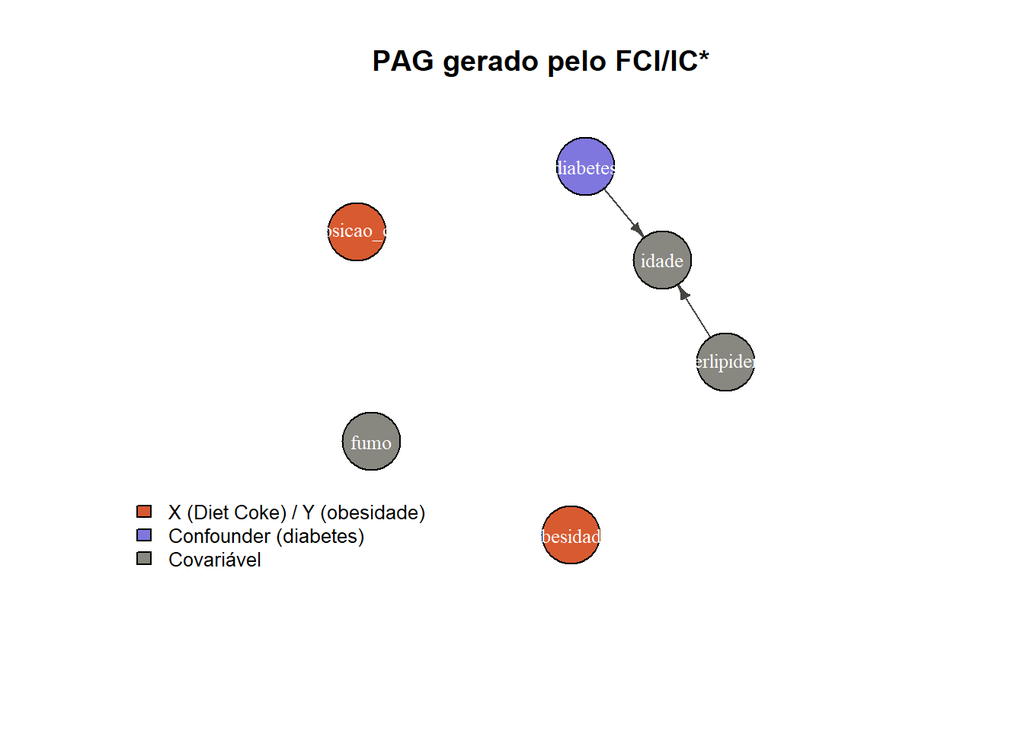

```r
amat <- fci_fit@amat
rownames(amat) <- colnames(df_model)
colnames(amat) <- colnames(df_model)

# Extrair arestas direcionadas
n       <- nrow(amat)
adj_dir <- matrix(0, n, n, dimnames = list(colnames(amat), colnames(amat)))
for (i in 1:n) for (j in 1:n)
  if (amat[i,j] == 2 && amat[j,i] == 3) adj_dir[i,j] <- 1

g <- graph_from_adjacency_matrix(adj_dir, mode = "directed", diag = FALSE)

cor_no <- function(name) {
  if (name %in% c("exposicao_coca", "obesidade")) return("#D85A30")
  if (name == "diabetes")                          return("#7F77DD")
  return("#888780")
}
V(g)$color <- sapply(V(g)$name, cor_no)

plot(g,
     vertex.color       = V(g)$color,
     vertex.label.color = "white",
     vertex.label.cex   = 0.8,
     vertex.size        = 32,
     edge.arrow.size    = 0.5,
     edge.color         = "#444441",
     layout             = layout_with_fr(g),
     main               = "PAG gerado pelo FCI/IC*")

legend("bottomleft",
       legend = c("X (Diet Coke) / Y (obesidade)", "Confounder (diabetes)", "Covariável"),
       fill   = c("#D85A30", "#7F77DD", "#888780"),
       bty    = "n", cex = 0.8)
```

## 3.3 DAG do artigo e critério backdoor

O artigo identifica a seguinte estrutura causal (Figura 5 de @qi2024causality):

**Código**

```r
dag_artigo <- dagitty('dag {
  exposicao_coca [exposure]
  obesidade      [outcome]
  exposicao_coca -> obesidade
  exposicao_coca -> diabetes
  diabetes       -> obesidade
  idade            -> obesidade
  idade            -> exposicao_coca
  genero           -> obesidade
  genero           -> exposicao_coca
  raca             -> obesidade
  escolaridade     -> obesidade
  escolaridade     -> exposicao_coca
  fumo             -> obesidade
  atividade_fisica -> obesidade
  atividade_fisica -> exposicao_coca
  hiperlipidemia   -> obesidade
  hiperlipidemia   -> exposicao_coca
}')

backdoor_sets <- adjustmentSets(dag_artigo, "exposicao_coca", "obesidade")
cat("Conjuntos de ajuste (backdoor criterion):\n")
```

```
Conjuntos de ajuste (backdoor criterion):
```

**Código**

```r
print(backdoor_sets)
```

```
{ atividade_fisica, escolaridade, genero, hiperlipidemia, idade }
```